# Assignment 3

## **Variable Comparison Chart**

*Description*: For the comparison part, I used bar chart to compare the ratio of population of jail to total population for black and white. This gives clear visualization that the ratio for black outweigh the ratio of white by almost 3 times. Though it doesn’t directly infer the prevalence of racial discrimination in criminal justice system, this is something to be looked into.

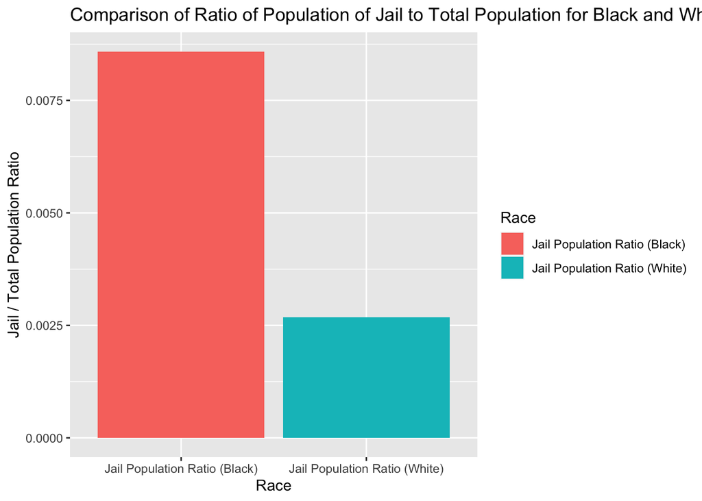

## **Map**

*Description*: The map shows the prison admission count for black across the U.S. Looking at the map, we are able to see which part of the US has the most, and least black prisoners. The darker the color is, the higher the count is for the black prison admission count.

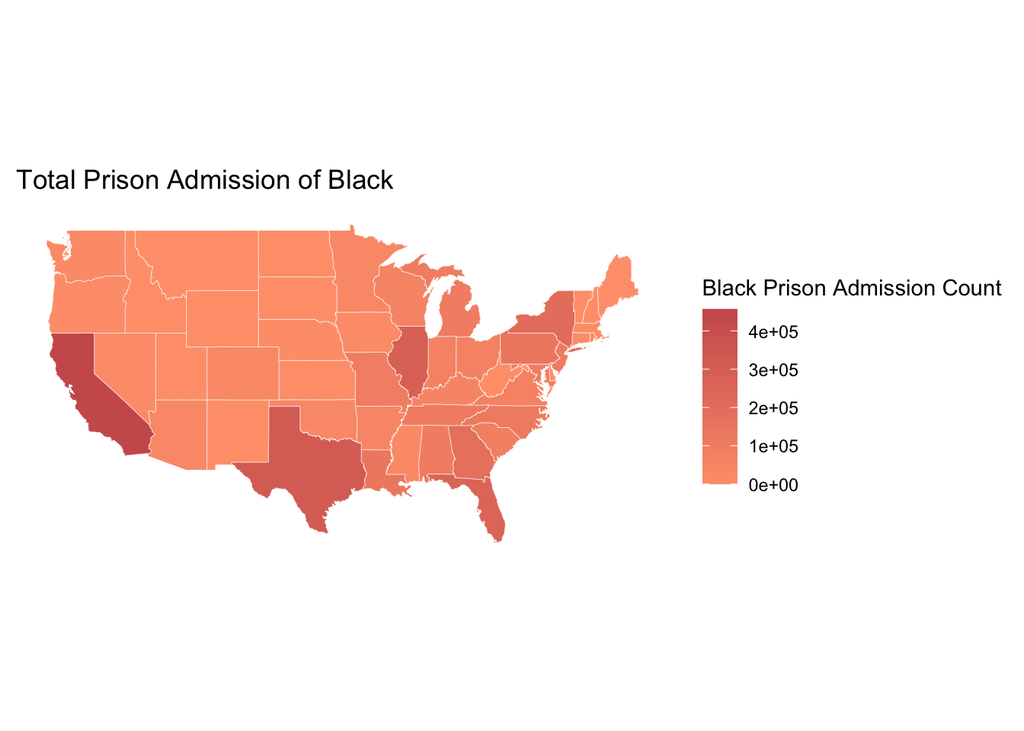